# Neural Networks Application: Ecosystem & simple ANNs (R)

Daniel S. Hain (dsh@business.aau.dk)

Updated November 11, 2020

```r
library(tidyverse)
library(magrittr)
```

# Introduction to `Keras`

- There are quite a bunch of deep learning frameworks around, from the older `Caffee` and `Theano` to Google’s `Tensorflow` and the newer `Pytorch` (which is increasingly trending in research).
- However, during the rest of this course, 95% of our deep learning exercises will be done using `Keras`
- Keras is a deep-learning framework that provides a convenient way to define and train almost any kind of deep-learning model. Keras was initially developed for researchers, with the aim of enabling fast experimentation.

It has the following advantages:

- User-friendly API which makes it easy to quickly prototype deep learning models.
- Built-in support for convolutional networks (for computer vision), recurrent networks (for sequence processing), and any combination of both.
- Supports arbitrary network architectures: multi-input or multi-output models, layer sharing, model sharing, etc., is therefore appropriate for building essentially any deep learning model, from a memory network to a neural Turing machine.
- Is capable of running on top of multiple back-ends including `TensorFlow`, `CNTK`, or `Theano`.
- Allows the same code to run on CPU or on GPU, and has strong multi-GPU, distributed storage, and training support (`Google cloud`, `Spark`, `HDF5`…)
- Can easily be integrated in AI products (Apple `CoreML`, `TensorFlow` Android runtime, `R` or `Python` webapp backend such as a `Shiny` or `Flask` app)

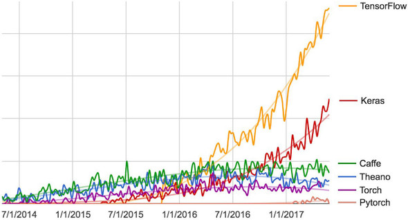

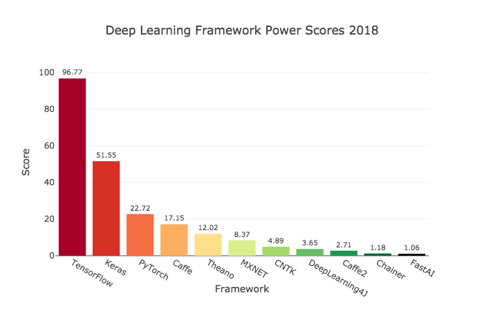

- So, after all, `Keras` represents a wonderful high-level starter, fast and easy implementable, and in most cases flexible enough to do whatever you feel like.

[figure not shown]

**Sidenote:** The weird name (`Keras`) means *horn* in Greek, and is a reference to ancient Greek literature. Eg., in Odyssey, supernatural *dream spirits* are divided between those who deceive men with false visions (arriving to Earth through a gate of ivory), and those who announce a future that will come to pass (arriving through a gate of horn). So, enough history lessons, let’s run our first deep learning model!

```r
# Load our main tool
library(keras)
```

# Our first deep learning model

## Introduction

- Well, its about time to get serious. We will dive straight in, and use a simple deep learning model on the classical `Mnist` dataset.
- This is the original data used by Jan LeCun and his team to fit an ANN that identifies handwritten digits for the US postal service.
- It consists of quite a bunch of samples of handwritten dicites together with their correct label. The wandwritten dicits here conveniently come as a 28x28 greyscale matrix, making them a good starter to warm up. Lets do that.

## Load our data and get ready

```r
# Load our data
mnist <- dataset_mnist()
```

```r
mnist %>%
  glimpse()
```

```
List of 2
 $ train:List of 2
  ..$ x: int [1:60000, 1:28, 1:28] 0 0 0 0 0 0 0 0 0 0 ...
  ..$ y: int [1:60000(1d)] 5 0 4 1 9 2 1 3 1 4 ...
 $ test :List of 2
  ..$ x: int [1:10000, 1:28, 1:28] 0 0 0 0 0 0 0 0 0 0 ...
  ..$ y: int [1:10000(1d)] 7 2 1 0 4 1 4 9 5 9 ...
```

```r
# sepperate in train and test
train_images <- mnist$train$x
train_labels <- mnist$train$y
test_images <- mnist$test$x
test_labels <- mnist$test$y
```

- Lets take a look at the structure.

```r
glimpse(train_images)
```

```
 int [1:60000, 1:28, 1:28] 0 0 0 0 0 0 0 0 0 0 ...
```

```r
glimpse(train_labels)
```

```
 int [1:60000(1d)] 5 0 4 1 9 2 1 3 1 4 ...
```

```r
digit <- train_images[5,,]
digit[,8:20] # I crop it a bit, otherwise the columns dont fit on one page
```

```
      [,1] [,2] [,3] [,4] [,5] [,6] [,7] [,8] [,9] [,10] [,11] [,12] [,13]
 [1,]    0    0    0    0    0    0    0    0    0     0     0     0     0
 [2,]    0    0    0    0    0    0    0    0    0     0     0     0     0
 [3,]    0    0    0    0    0    0    0    0    0     0     0     0     0
 [4,]    0    0    0    0    0    0    0    0    0     0     0     0     0
 [5,]    0    0    0    0    0    0    0    0    0     0     0     0     0
 [6,]    0    0    0    0    0    0    0    0    0     0     0     0     0
 [7,]    0    0    0    0    0    0    0    0    0     0     0     0     0
 [8,]    0    0    0    0    0   55  148  210  253   253   113    87   148
 [9,]    0    0    0    0   87  232  252  253  189   210   252   252   253
[10,]    0    0    4   57  242  252  190   65    5    12   182   252   253
[11,]    0    0   96  252  252  183   14    0    0    92   252   252   225
[12,]    0  132  253  252  146   14    0    0    0   215   252   252    79
[13,]  126  253  247  176    9    0    0    8   78   245   253   129     0
[14,]  232  252  176    0    0    0   36  201  252   252   169    11     0
[15,]  252  252   30   22  119  197  241  253  252   251    77     0     0
[16,]  231  252  253  252  252  252  226  227  252   231     0     0     0
[17,]   55  235  253  217  138   42   24  192  252   143     0     0     0
[18,]    0    0    0    0    0    0   62  255  253   109     0     0     0
[19,]    0    0    0    0    0    0   71  253  252    21     0     0     0
[20,]    0    0    0    0    0    0    0  253  252    21     0     0     0
[21,]    0    0    0    0    0    0   71  253  252    21     0     0     0
[22,]    0    0    0    0    0    0  106  253  252    21     0     0     0
[23,]    0    0    0    0    0    0   45  255  253    21     0     0     0
[24,]    0    0    0    0    0    0    0  218  252    56     0     0     0
[25,]    0    0    0    0    0    0    0   96  252   189    42     0     0
[26,]    0    0    0    0    0    0    0   14  184   252   170    11     0
[27,]    0    0    0    0    0    0    0    0   14   147   252    42     0
[28,]    0    0    0    0    0    0    0    0    0     0     0     0     0
```

To make it more tangible, lets plot one:

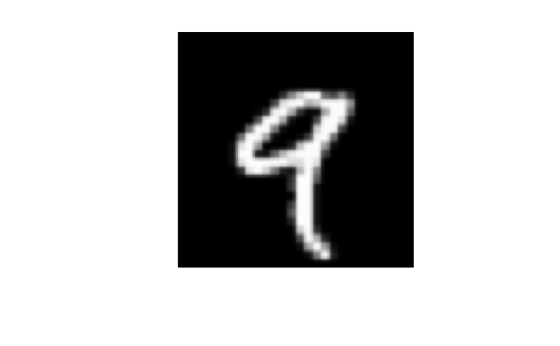

```r
digit %>% as.raster(max = 255) %>% plot()
```

```r
rm(digits)
```

## Define the `Keras` model

The workflow will be as follows:

1. First, we’ll feed the neural network the training data, `train_images` and `train_labels`.
2. The network will then learn to associate images and labels.
3. Finally, we’ll ask the network to produce predictions for `test_images`, and we’ll verify whether these predictions match the labels from `test_labels`.

Let’s build the network - again, remember that you aren’t expected to understand everything about this example yet.

Building a model in `Keras` that can be fitted on your data involves two steps:

1. Defining the networks architecture interms of layers and their shape.
2. Compiling the model, and defining the loss function, evaluation metric, and optimizer.

```r
network <- keras_model_sequential() %>%
  layer_dense(units = 512, activation = "relu", input_shape = c(28 * 28)) %>%
  layer_dense(units = 10, activation = "softmax")
```

Notice that the layer stacking in `R` is done via the well-known `%>%`, in `Pyhton` with `.`. That’s about the main difference between both implementations.

```r
network %>% compile(
  optimizer = "rmsprop",
  loss = "categorical_crossentropy",
  metrics = c("accuracy")
)
```

Lets inspect our final setup:

```r
summary(network)
```

```
Model: "sequential_1"
___________________________________________________________________________________________________
Layer (type)                                Output Shape                            Param #
===================================================================================================
dense_2 (Dense)                             (None, 512)                             401920
___________________________________________________________________________________________________
dense_3 (Dense)                             (None, 10)                              5130
===================================================================================================
Total params: 407,050
Trainable params: 407,050
Non-trainable params: 0
___________________________________________________________________________________________________
```

## Preprocess the data

- Before training the model, preprocess the data by reshaping it into the shape the network expects and scaling it so that all values are in the `[0, 1]` interval.
- Previously, our training images were stored in an 3d array of shape `(60000, 28, 28)` of type integer with values in the `[0, 255]` interval.
- We transform it into a double array of shape `(60000, 28 * 28)` with values between `0` and `1`.

```r
train_images <- array_reshape(train_images, c(60000, 28 * 28))
train_images <- train_images / 255 # To scale between 0 and 1

test_images <- array_reshape(test_images, c(10000, 28 * 28))
test_images <- test_images / 255 # To scale between 0 and 1
```

- Note that we use the `array_reshape()` rather than the `dim()` function to reshape the array. I explain why later, when we talk about **tensor reshaping**.
- Lastly, we also need to categorically encode the labels.

```r
train_labels <- to_categorical(train_labels)
test_labels <- to_categorical(test_labels)
```

## Run the network

We’re now ready to train the network via `Keras` `fit()` function. We save the output in an object we call `history.net`.

```r
set.seed(1337)
history.net <- network %>% fit(x = train_images,
                               y = train_labels,
                               epochs = 10, # How often shall we re-run the model on the whole sample
                               batch_size = 128, # How many observations should be included in every batch
                               validation_split = 0.25 # If we want to do a  cross-validation in the training
                               )
```

```r
history.net
```

```
Final epoch (plot to see history):
        loss: 0.01011
    accuracy: 0.9972
    val_loss: 0.09245
val_accuracy: 0.9765
```

```r
history.net %>% glimpse()
```

```
List of 2
 $ params :List of 3
  ..$ verbose: int 1
  ..$ epochs : int 10
  ..$ steps  : int 352
 $ metrics:List of 4
  ..$ loss        : num [1:10] 0.2928 0.1205 0.0775 0.0555 0.0411 ...
  ..$ accuracy    : num [1:10] 0.914 0.965 0.977 0.984 0.988 ...
  ..$ val_loss    : num [1:10] 0.1599 0.1126 0.1008 0.0989 0.087 ...
  ..$ val_accuracy: num [1:10] 0.953 0.966 0.971 0.972 0.975 ...
 - attr(*, "class")= chr "keras_training_history"
```

We can also visualize these metrics through the epocs.

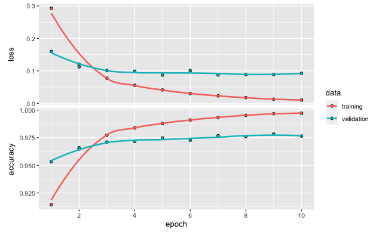

```r
history.net %>% plot(smooth = TRUE)
```

```r
metrics <- network %>% evaluate(test_images, test_labels)
```

```r
metrics
```

```
      loss   accuracy
0.06924154 0.98210001
```

- Ok, so far so good. I think that’s a decent accuracy for such an ad-hoc model. Whith a bit of tinkering, we surely could get it to 99%. But thats a task for another time…
- Lets go back to basic and revise a bit what we have done so far.

# Data representations for neural networks

- In the previous example, we started from data stored in multidimensional arrays, also called **tensors**.
- In general, most current ML systems use tensors as their basic data structure. Tensors are fundamental to the field-so fundamental that Google’s **TensorFlow** was named after them. So what’s a tensor?
- Tensors are a generalization of vectors and matrices to an arbitrary number of dimensions (note that in the context of tensors, a dimension is often called an axis). In `R`, vectors are used to create and manipulate 1D tensors, and matrices are used for 2D tensors. For higher-level dimensions, array objects (which support any number of dimensions) are used.

## Key tensor-attributes

A tensor is defined by three key attributes:

1. **Number of axes** (rank): For instance, a 3D tensor has three axes, and a matrix has two axes.
2. **Shape:** This is an integer vector that describes how many dimensions the tensor has along each axis.
3. **Data type:** This is the type of the data contained in the tensor; for instance, a tensor’s type could be integer or double. On rare occasions, you may see a character tensor. But because tensors live in preallocated contiguous memory segments, and strings, being variable-length, would preclude the use of this implementation, they’re rarely used.

## Tensor reshaping

Remember that we before did not use the `dim()` but the `array_reshape()` function to manipulate our input tensors.

```r
train_images <- array_reshape(train_images, c(60000, 28 * 28))
```

```r
str(train_images)
```

[output not shown]

```r
dim(train_images)
```

[output not shown]

- This is an `R` specific thingy, so that the data is reinterpreted using row-major semantics (as opposed to `R`s default column-major semantics), which is in turn compatible with the way the numerical libraries called by `Keras` (`NumPy`, `TensorFlow`, and so on) interpret array dimensions.
- You should always use the `array_reshape()` function when reshaping `R` arrays that will be passed to `Keras`.
- Reshaping a tensor means rearranging its rows and columns to match a target shape.
- Naturally, the reshaped tensor has the same total number of coefficients as the initial tensor. Lets do a simple examples:

```r
x <- matrix(c(0:5),
            nrow = 3, ncol = 2, byrow = TRUE)
x
```

[output not shown]

```r
x <- array_reshape(x, dim = c(3, 2))
x
```

[output not shown]

```r
x <- array_reshape(x, dim = c(2, 3))
x
```

[output not shown]

- A special case of reshaping that’s commonly encountered is *transposition*.
- Transposing a matrix means exchanging its rows and its columns, so that `x[i,]` becomes `x[, i]`. The `t()` function can be used to transpose a matrix:

```r
x <- t(x)
x
```

[output not shown]

```r
rm(x)
```

## Geometric interpretation of tensor operations

```r
layer <- layer_dense(units = 32, input_shape = c(784))
```

- We’re creating a layer that will only accept as input 2D tensors where the first dimension is 784 (the first dimension, the batch dimension, is unspecified, and thus any value would be accepted). This layer will return a tensor where the first dimension has been transformed to be 32.
- Thus this layer can only be connected to a downstream layer that expects 32-dimensional vectors as its input. When using Keras, you don’t have to worry about compatibility, because the layers you add to your models are dynamically built to match the shape of the incoming layer.
- For instance, suppose you write the following:

```r
model <- keras_model_sequential() %>%
  layer_dense(units = 32, input_shape = c(784)) %>%
  layer_dense(units = 32)
```

```r
model
```

[output not shown]

```r
# devtools::install_github("andrie/deepviz")
library(deepviz)
plot_model(model)
```

[output not shown]

```r
rm(layer, model)
```

## Activation functions

- As we already saw, we can define activation functiopns for the different activation functions for every layer. While we within the intermediate layers seldomely switch between different activation functions, the one we define for the output layer critically depends on the shape of our desired output data.
- A brief reminder: Activation functions transform the input weights of a cell to its output. Without them, the dense layer would consist of two linear operations-a dot product and an addition:
- In order to get access to a much richer hypothesis space that would benefit from deep representations, you need a non-linearity, or activation function.
  - `relu` is the most popular activation function in deep learning, but there are many other candidates, which all come with similarly strange names: `prelu`, `elu`, and so on. A `relu` (rectified linear unit) is a function meant to zero out negative values, and commonly used for intermediate layers (formerly, almost all layers where modelled with `sigmoid`, but nowadays its proven that for intermediate layers `relu` mostly works better).

[figure not shown]

Our output layer, however, should model a binary choice (yes/no classification). For such a model, we would in a 2-class problem commonly use a a `sigmoid` function, which we already know from logistic regression models. It “squashes” arbitrary values into the `[0, 1]` interval, outputting something that can be interpreted as a probability.

[figure not shown]

However, since we have a multi-class prediction problem, we choose `softmax`, which squashes the outputs of each unit to be between `0` and `1`, just like a `sigmoid`, but it also divides each output such that the total sum of the outputs is equal to `1`. The output is equivalent to a categorical probability distribution, it tells you the probability that any of the classes are true.

If you are interested regarding the different types of layers in `Keras`, check [the reference site](https://keras.rstudio.com/reference/index.html) with all layers implemented. Furthermore, types of activation functions are discussed [HERE](https://medium.com/the-theory-of-everything/understanding-activation-functions-in-neural-networks-9491262884e0)

## Loss functions and optimizers: keys to configuring the learning process

Once the network architecture is defined, you still have to choose two more things:

- **Loss function** (objective function): The quantity that will be minimized during training. It represents a measure of success for the task at hand.
- **Optimizer:** Determines how the network will be updated based on the loss function. It implements a specific variant of stochastic gradient descent (SGD).
- Choosing the right objective and function for the right problem is extremely important: your network will take any shortcut it can, to minimize the loss; so if the objective doesn’t fully correlate with success for the task at hand, your network will end up doing things you may not have wanted.
- [HERE](https://towardsdatascience.com/understanding-different-loss-functions-for-neural-networks-dd1ed0274718) you find a brief overview on different loss functions. Fortunately, when it comes to common problems such as classification, regression, and sequence prediction, there are simple guidelines you can follow to choose the correct loss.
- Take this rule-of-thumb table as a good starter:

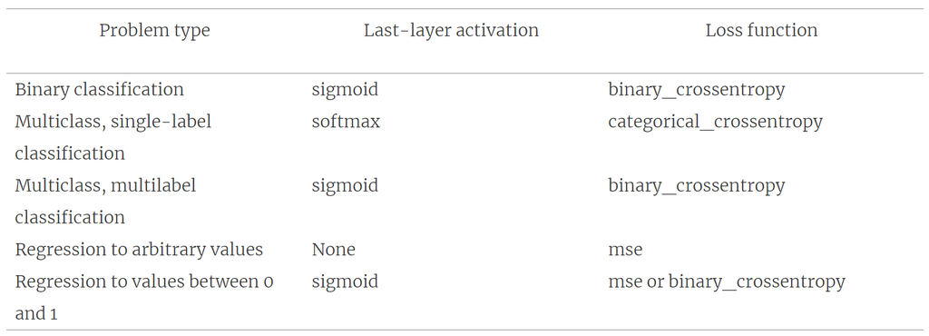

- With respect to the `optimizer`: We will cover that later. There are a bunch of different around, most variants of the **Stochastic Gradient Descent (SGD)**, **Batch (vanilla) Gradient Descent**, and **Mini-Batch Gradient Descent**.
- [HERE](https://medium.com/@sdoshi579/optimizers-for-training-neural-network-59450d71caf6) and [HERE](http://ruder.io/optimizing-gradient-descent/) you find a nice summary for the interested reader that wants to now more. Currently (that might change soon, since everything in DL movers fast), its common knowledge that if you have nmo strong reasons to believe so, `RMSprop` (an unpublished, adaptive learning rate method proposed by Geoff Hinton) with standard learning rates works just well.

# Reviewing our initial example

Let’s go back to the first example and review each piece of it in the light of what we have learned up to now: This was the input data:

```r
mnist <- dataset_mnist()

train_images <- mnist$train$x
train_images <- array_reshape(train_images, c(60000, 28 * 28))
train_images <- train_images / 255

test_images <- mnist$test$x
test_images <- array_reshape(test_images, c(10000, 28 * 28))
test_images <- test_images / 255
```

- Now you understand that the input images are stored in tensors of shape `(60000, 784)` (training data) and `(10000, 784)` (test data), respectively.
- This was our network:

```r
network <- keras_model_sequential() %>%
  layer_dense(units = 512, activation = "relu", input_shape = c(28*28)) %>%
  layer_dense(units = 10, activation = "softmax")
```

- Now you understand that this network consists of a chain of two dense layers, that each layer applies a few simple tensor operations to the input data, and that these operations involve weight tensors.
- We know that `layer_dense()` creates fully connected layers, so there exists a weight between every element of one with every element of the following layer.
- Weight tensors, which are attributes of the layers, are where the knowledge of the network persists. We know the 2nd layer has `512` cells, the final output layer `10` (equal to the number of classes to predict). Finally, we know that every cell also contains a non-linear activation function, such as `relu`, `sigmoid`, or `softmax`.

This was the network-compilation step:

```r
network network %>% compile(
  optimizer = "rmsprop",
  loss = "categorical_crossentropy",
  metrics = "accuracy"
  )
```

- Now you understand that `categorical_crossentropy` (a measure how pure the predicted classes are) is a type of a `loss`` function that’s used as a feedback signal for learning the weight tensors, and which the training phase will attempt to minimize.
- You also know that this reduction of the loss happens via mini-batch stochastic gradient descent. The exact rules governing a specific use of gradient descent are defined by the `rmsprop` optimizer passed as the first argument.

Finally, this was the training loop:

```r
network %>% fit(x = train_images,
                y = train_labels,
                epochs = 10,
                batch_size = 128)
```

At this point, you already know most of what there is to know about the basics of neural networks.

However, there is still some stuff to come, namely:

1. How to use architectures other that the simple **feed-forward** one.
2. How to fight overfitting
3. How to specify training routines and parameter grid-search
4. And some more…

But for that, there will be other sessions top come…

# Example on tabular data

- Just to make it a bit lss abstract and work with tabular data, lets give it a shot with classifying penguins :)

## Load data

```r
library(tidymodels)
```

```r
data <- read_csv("https://github.com/allisonhorst/palmerpenguins/raw/5b5891f01b52ae26ad8cb9755ec93672f49328a8/data/penguins_size.csv")
```

```r
data %>% glimpse()
```

[output not shown]

## TRain TEst split

```r
data %<>%
  rename(y = species_short) %>%
  relocate(y) %>%
  drop_na()
```

```r
data_split <- initial_split(data, prop = 0.75, strata = y)

data_train <- data_split  %>%  training()
data_test <- data_split %>% testing()
```

## Preprocessing recipe

```r
data_recipe <- data_train %>%
  recipe(y ~.) %>%
  step_center(all_numeric(), -all_outcomes()) %>% # Centers all numeric variables to mean = 0
  step_scale(all_numeric(), -all_outcomes()) %>% # scales all numeric variables to sd = 1
  step_dummy(all_nominal(), one_hot = TRUE) %>%
  prep()
```

```r
x_train <- juice(data_recipe) %>% select(-starts_with('y')) %>% as.matrix()
x_test <- bake(data_recipe, new_data = data_test) %>% select(-starts_with('y')) %>% as.matrix()
```

```r
y_train <- juice(data_recipe)  %>% select(starts_with('y')) %>% as.matrix()
y_test <- bake(data_recipe, new_data = data_test) %>% select(starts_with('y')) %>% as.matrix()
```

# Define the network

```r
model_keras <- keras_model_sequential()
```

```r
model_keras %>%
  # First hidden layer
  layer_dense(
    units              = 12,
    activation         = "relu",
    input_shape        = ncol(x_train)) %>%
  # Dropout to prevent overfitting
#  layer_dropout(rate = 0.1) %>%
  # Second hidden layer
  layer_dense(
    units              = 12,
    activation         = "relu") %>%
  # Dropout to prevent overfitting
 # layer_dropout(rate = 0.1) %>%
  # Output layer
  layer_dense(
    units              = ncol(y_train),
    activation         = "softmax")
```

```r
model_keras %>%
  compile(
    optimizer = "adam",
    loss = "categorical_crossentropy",
    metrics = "accuracy"
  )
```

```r
model_keras_hist <- model_keras  %>% fit(x = x_train,
                                         y = y_train,
                                         epochs = 10, # How often shall we re-run the model on the whole sample
                                         batch_size = 12, # How many observations should be included in every batch
                                         #validation_split = 0.25 # If we want to do a  cross-validation in the training
                                         )
```

# Endnotes

### More info

You can find more info about:

- `keras` [here](https://keras.rstudio.com/): Excellent documentation, tutorials, and resources regarding `keras`, maintained by Rstudio

### Online Resources

Datacamp * [Introduction to TensorFlow in R](https://learn.datacamp.com/courses/introduction-to-tensorflow-in-r): A bit low-level, but a good intro for starters * Also follow the Python intros, they might still be helpful for you.